# Ford GoBike Data Exploration

## Preliminary Wrangling

> This document explores a dataset containing individual rides made in Ford GoBike covering the greater San Francisco Bay area in January.

```python
# import all packages and set plots to be embedded inline
import numpy as np
import pandas as pd
import matplotlib.pyplot as plt
import seaborn as sb

%matplotlib inline
```

```python
# load in the dataset into a pandas dataframe
df = pd.read_csv('201801-fordgobike-tripdata.csv')
```

```python
df.head()
```

|  | duration_sec | start_time | end_time | start_station_id | start_station_name | start_station_latitude | start_station_longitude | end_station_id | end_station_name | end_station_latitude | end_station_longitude | bike_id | user_type | member_birth_year | member_gender | bike_share_for_all_trip |
| --- | --- | --- | --- | --- | --- | --- | --- | --- | --- | --- | --- | --- | --- | --- | --- | --- |
| 0 | 75284 | 2018-01-31 22:52:35.2390 | 2018-02-01 19:47:19.8240 | 120 | Mission Dolores Park | 37.761420 | -122.426435 | 285 | Webster St at O'Farrell St | 37.783521 | -122.431158 | 2765 | Subscriber | 1986.0 | Male | No |
| 1 | 85422 | 2018-01-31 16:13:34.3510 | 2018-02-01 15:57:17.3100 | 15 | San Francisco Ferry Building (Harry Bridges Pl... | 37.795392 | -122.394203 | 15 | San Francisco Ferry Building (Harry Bridges Pl... | 37.795392 | -122.394203 | 2815 | Customer | NaN | NaN | No |
| 2 | 71576 | 2018-01-31 14:23:55.8890 | 2018-02-01 10:16:52.1160 | 304 | Jackson St at 5th St | 37.348759 | -121.894798 | 296 | 5th St at Virginia St | 37.325998 | -121.877120 | 3039 | Customer | 1996.0 | Male | No |
| 3 | 61076 | 2018-01-31 14:53:23.5620 | 2018-02-01 07:51:20.5000 | 75 | Market St at Franklin St | 37.773793 | -122.421239 | 47 | 4th St at Harrison St | 37.780955 | -122.399749 | 321 | Customer | NaN | NaN | No |
| 4 | 39966 | 2018-01-31 19:52:24.6670 | 2018-02-01 06:58:31.0530 | 74 | Laguna St at Hayes St | 37.776435 | -122.426244 | 19 | Post St at Kearny St | 37.788975 | -122.403452 | 617 | Subscriber | 1991.0 | Male | No |

```python
df.info()
```

```
<class 'pandas.core.frame.DataFrame'>
RangeIndex: 94802 entries, 0 to 94801
Data columns (total 16 columns):
duration_sec               94802 non-null int64
start_time                 94802 non-null object
end_time                   94802 non-null object
start_station_id           94802 non-null int64
start_station_name         94802 non-null object
start_station_latitude     94802 non-null float64
start_station_longitude    94802 non-null float64
end_station_id             94802 non-null int64
end_station_name           94802 non-null object
end_station_latitude       94802 non-null float64
end_station_longitude      94802 non-null float64
bike_id                    94802 non-null int64
user_type                  94802 non-null object
member_birth_year          86963 non-null float64
member_gender              87001 non-null object
bike_share_for_all_trip    94802 non-null object
dtypes: float64(5), int64(4), object(7)
memory usage: 11.6+ MB
```

```python
#Only select data when member_birth_year is not null
df= df[df.member_birth_year.notnull()]
```

```python
#Convert start_time from object to datatime
df['start_time'] = pd.to_datetime(df['start_time'])
```

```python
#Select hour and weekday from start_time and create two columns
df['hour']= df.start_time.dt.hour
df['weekday']= df.start_time.dt.weekday_name
```

```python
df.head()
```

|  | duration_sec | start_time | end_time | start_station_id | start_station_name | start_station_latitude | start_station_longitude | end_station_id | end_station_name | end_station_latitude | end_station_longitude | bike_id | user_type | member_birth_year | member_gender | bike_share_for_all_trip | hour | weekday |
| --- | --- | --- | --- | --- | --- | --- | --- | --- | --- | --- | --- | --- | --- | --- | --- | --- | --- | --- |
| 0 | 75284 | 2018-01-31 22:52:35.239 | 2018-02-01 19:47:19.8240 | 120 | Mission Dolores Park | 37.761420 | -122.426435 | 285 | Webster St at O'Farrell St | 37.783521 | -122.431158 | 2765 | Subscriber | 1986.0 | Male | No | 22 | Wednesday |
| 2 | 71576 | 2018-01-31 14:23:55.889 | 2018-02-01 10:16:52.1160 | 304 | Jackson St at 5th St | 37.348759 | -121.894798 | 296 | 5th St at Virginia St | 37.325998 | -121.877120 | 3039 | Customer | 1996.0 | Male | No | 14 | Wednesday |
| 4 | 39966 | 2018-01-31 19:52:24.667 | 2018-02-01 06:58:31.0530 | 74 | Laguna St at Hayes St | 37.776435 | -122.426244 | 19 | Post St at Kearny St | 37.788975 | -122.403452 | 617 | Subscriber | 1991.0 | Male | No | 19 | Wednesday |
| 6 | 453 | 2018-01-31 23:53:53.632 | 2018-02-01 00:01:26.8050 | 110 | 17th & Folsom Street Park (17th St at Folsom St) | 37.763708 | -122.415204 | 134 | Valencia St at 24th St | 37.752428 | -122.420628 | 3571 | Subscriber | 1988.0 | Male | No | 23 | Wednesday |
| 7 | 180 | 2018-01-31 23:52:09.903 | 2018-01-31 23:55:10.8070 | 81 | Berry St at 4th St | 37.775880 | -122.393170 | 93 | 4th St at Mission Bay Blvd S | 37.770407 | -122.391198 | 1403 | Subscriber | 1980.0 | Male | No | 23 | Wednesday |

```python
#Now we have total 86963 rows for this dataframe
df.info()
```

```
<class 'pandas.core.frame.DataFrame'>
Int64Index: 86963 entries, 0 to 94801
Data columns (total 18 columns):
duration_sec               86963 non-null int64
start_time                 86963 non-null datetime64[ns]
end_time                   86963 non-null object
start_station_id           86963 non-null int64
start_station_name         86963 non-null object
start_station_latitude     86963 non-null float64
start_station_longitude    86963 non-null float64
end_station_id             86963 non-null int64
end_station_name           86963 non-null object
end_station_latitude       86963 non-null float64
end_station_longitude      86963 non-null float64
bike_id                    86963 non-null int64
user_type                  86963 non-null object
member_birth_year          86963 non-null float64
member_gender              86963 non-null object
bike_share_for_all_trip    86963 non-null object
hour                       86963 non-null int64
weekday                    86963 non-null object
dtypes: datetime64[ns](1), float64(5), int64(5), object(7)
memory usage: 12.6+ MB
```

```python
#Convert member_birth_year from float to int
df.member_birth_year = df.member_birth_year.astype(int)
```

```python
#Get the age of each member to make data easier to see
df.member_birth_year = 2018 - df.member_birth_year
df.rename(columns={'member_birth_year':'age'}, inplace=True)
```

```python
#Convert sec to min and rename duration_sec to duration_min
df.duration_sec = df.duration_sec /60
df.rename(columns={'duration_sec':'duration_min'}, inplace=True)
```

```python
df.head()
```

|  | duration_min | start_time | end_time | start_station_id | start_station_name | start_station_latitude | start_station_longitude | end_station_id | end_station_name | end_station_latitude | end_station_longitude | bike_id | user_type | age | member_gender | bike_share_for_all_trip | hour | weekday |
| --- | --- | --- | --- | --- | --- | --- | --- | --- | --- | --- | --- | --- | --- | --- | --- | --- | --- | --- |
| 0 | 1254.733333 | 2018-01-31 22:52:35.239 | 2018-02-01 19:47:19.8240 | 120 | Mission Dolores Park | 37.761420 | -122.426435 | 285 | Webster St at O'Farrell St | 37.783521 | -122.431158 | 2765 | Subscriber | 32 | Male | No | 22 | Wednesday |
| 2 | 1192.933333 | 2018-01-31 14:23:55.889 | 2018-02-01 10:16:52.1160 | 304 | Jackson St at 5th St | 37.348759 | -121.894798 | 296 | 5th St at Virginia St | 37.325998 | -121.877120 | 3039 | Customer | 22 | Male | No | 14 | Wednesday |
| 4 | 666.100000 | 2018-01-31 19:52:24.667 | 2018-02-01 06:58:31.0530 | 74 | Laguna St at Hayes St | 37.776435 | -122.426244 | 19 | Post St at Kearny St | 37.788975 | -122.403452 | 617 | Subscriber | 27 | Male | No | 19 | Wednesday |
| 6 | 7.550000 | 2018-01-31 23:53:53.632 | 2018-02-01 00:01:26.8050 | 110 | 17th & Folsom Street Park (17th St at Folsom St) | 37.763708 | -122.415204 | 134 | Valencia St at 24th St | 37.752428 | -122.420628 | 3571 | Subscriber | 30 | Male | No | 23 | Wednesday |
| 7 | 3.000000 | 2018-01-31 23:52:09.903 | 2018-01-31 23:55:10.8070 | 81 | Berry St at 4th St | 37.775880 | -122.393170 | 93 | 4th St at Mission Bay Blvd S | 37.770407 | -122.391198 | 1403 | Subscriber | 38 | Male | No | 23 | Wednesday |

```python
#see the summary of the dataframe
df.describe()
```

|  | duration_min | start_station_id | start_station_latitude | start_station_longitude | end_station_id | end_station_latitude | end_station_longitude | bike_id | age | hour |
| --- | --- | --- | --- | --- | --- | --- | --- | --- | --- | --- |
| count | 86963.000000 | 86963.000000 | 86963.000000 | 86963.000000 | 86963.000000 | 86963.000000 | 86963.000000 | 86963.000000 | 86963.000000 | 86963.000000 |
| mean | 12.139881 | 103.955924 | 37.773672 | -122.361498 | 101.108920 | 37.773819 | -122.360538 | 2047.972057 | 37.067580 | 13.202465 |
| std | 30.022394 | 86.990169 | 0.084847 | 0.104488 | 85.782165 | 0.084629 | 0.103763 | 1092.624499 | 10.803017 | 4.674556 |
| min | 1.016667 | 3.000000 | 37.317298 | -122.444293 | 3.000000 | 37.317298 | -122.444293 | 11.000000 | 18.000000 | 0.000000 |
| 25% | 5.850000 | 30.000000 | 37.771662 | -122.412408 | 28.000000 | 37.772406 | -122.411306 | 1130.000000 | 29.000000 | 9.000000 |
| 50% | 8.933333 | 80.000000 | 37.781270 | -122.398525 | 77.000000 | 37.781383 | -122.397405 | 2150.000000 | 35.000000 | 13.000000 |
| 75% | 13.450000 | 160.000000 | 37.795392 | -122.390428 | 157.000000 | 37.795392 | -122.390428 | 3016.000000 | 43.000000 | 17.000000 |
| max | 1410.150000 | 342.000000 | 37.880222 | -121.874119 | 342.000000 | 37.880222 | -121.874119 | 3744.000000 | 118.000000 | 23.000000 |

### What is the structure of your dataset?

> There are 94802 individual rides in the dataset with 16 features(duration_sec,start_station_id, user_type, etc) at the beginning. After cleaning null data for member_birth_year, it has 86963 rows now. Most variables are numeric in nature, but variables like bike_share_for_all_trip, user_type,and end_station_name are categorcial.

### What is/are the main feature(s) of interest in your dataset?

> I am interested in figuring out what features made the large proportion of bike usage for Ford Gobike in January.

### What features in the dataset do you think will help support your investigation into your feature(s) of interest?

> I expect that user_type will have the strongest effect on bike usage: If people are Subscriber, they are more likely would use GoBike frequently. Also, I believe hour, age, and location have effects on the bike usage.

## Univariate Exploration

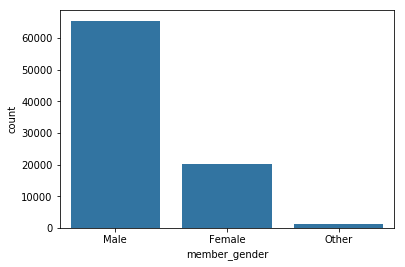

```python
#investigate the distribution of gender in bike usage
base_color = sb.color_palette()[0]
sb.countplot(data = df, x = 'member_gender', color= base_color);
```

From this plot, we can see that male members are the majority of GoBike users. The ratio of male to female members are about 3:1.

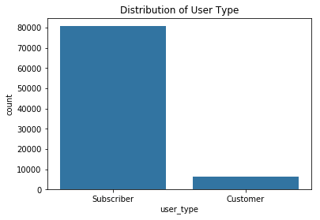

```python
#investigate the distribution of user type in bike usage
base_color = sb.color_palette()[0]
plt.title('Distribution of User Type')
sb.countplot(data = df, x = 'user_type', color= base_color);
```

From the plot, we can see that the majority of rides are made by subscriber. Only few portion of bike users is customer.

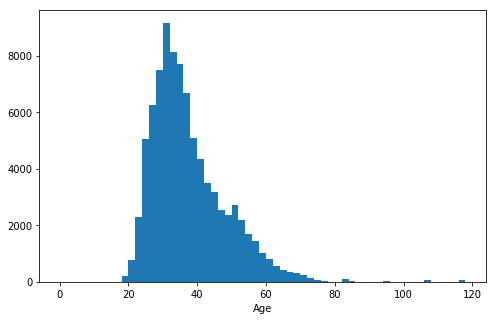

```python
#Use histgram to plot bike usage on Age
bins = np.arange(0, df['age'].max()+2, 2)

plt.figure(figsize=[8, 5])
plt.hist(data = df, x = 'age', bins = bins)
plt.xlabel('Age');
```

```python
#Check outliers and the sum of ourliers
high_outliers = (df['age'] > 80)
print(high_outliers.sum())
df_high = df.loc[df['age'] > 80]
df_high.age.value_counts()
```

```
284
```

```
82     82
107    60
116    30
83     30
94     28
118    26
85     14
90      9
84      5
Name: age, dtype: int64
```

```python
#To be realistic, I only select data with age is less than 80
df_new = df.query('age < 80')
```

[output not shown]

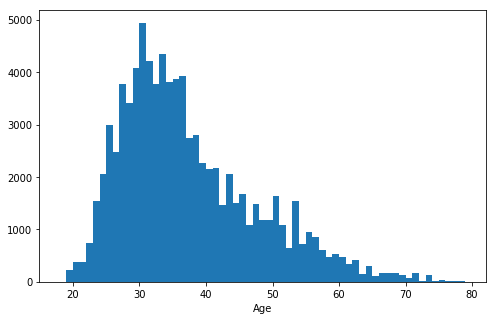

```python
#investigate bike usage on Age without outliers
bins = np.arange(18, df_new['age'].max()+1, 1)

plt.figure(figsize=[8, 5])
plt.hist(data = df_new, x = 'age', bins = bins)
plt.xlabel('Age')

df_new.age.mean()
```

The distribution shows that the age of majority bike users range from mid 20 to mid 30. The mean of this distirbution is 36.9

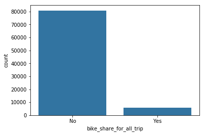

```python
#investigate bike usage on bike_share_for_all_trip
base_color = sb.color_palette()[0]
sb.countplot(data = df_new, x = 'bike_share_for_all_trip', color= base_color);
```

Before plotting this chart, I thought there would be more members applied to bike share for all program. It helps low income residents save money on their transporation. However, the result is actually the opposite. The majority of bike users do not apply to this program.

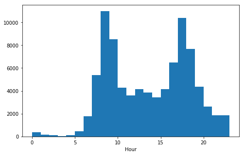

```python
#investigate the distribution of Hour in bike usage
bins = np.arange(0, df_new['hour'].max()+1, 1)

plt.figure(figsize=[8, 5])
plt.hist(data = df_new, x = 'hour', bins = bins)
plt.xlabel('Hour');
```

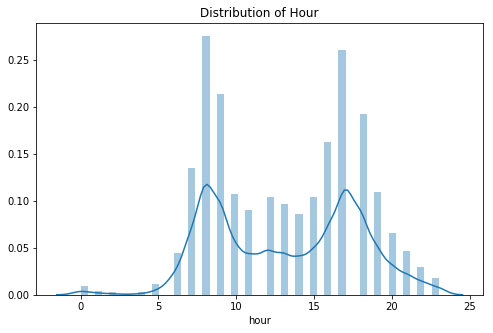

```python
#use displot for specifying histogram bins
plt.figure(figsize=[8, 5])
plt.title('Distribution of Hour')
sb.distplot(df_new['hour']);
```

The plot shows the peak usage at 8 am and 5 pm. It indicates that shared bikes are used as a mean of commuting to work.

```python
ordinal_var_dict = {'weekday': ['Sunday','Monday','Tuesday','Wednesday','Thursday','Friday','Saturday']}

for var in ordinal_var_dict:
    ordered_var = pd.api.types.CategoricalDtype(ordered = True,
                                                categories = ordinal_var_dict[var])
    df_new[var] = df_new[var].astype(ordered_var)
```

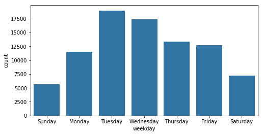

```python
#investigate the distribution of weekday in bike usage
plt.figure(figsize=[8, 4])
base_color = sb.color_palette()[0]
sb.countplot(data = df_new, x = 'weekday', color= base_color);
```

From the plot above, we can clearly see that the usage over the weekdays is greater than over weekends. This confirm that bike user are more likely to use bike on weekdays.

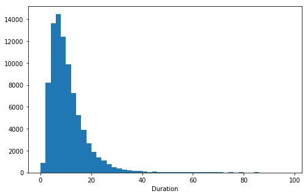

```python
#investigate the average duraiton for each ride
bins = np.arange(0, 100, 2)

plt.figure(figsize=[8, 5])
plt.hist(data = df_new, x = 'duration_min', bins= bins)
plt.xlabel('Duration');
```

The distribution is skewed to the right. It shows that members usually use bike for short trips. We can see about 90% of rides are under 20 mins.

### Discuss the distribution(s) of your variable(s) of interest. Were there any unusual points? Did you need to perform any transformations?

> When I looked at the usage for hour, I saw two peak between 5 to 10 and 15 to 20. After I used distplot, I can see that there are more people use bike at 8 am and 5 pm. The usage of this two hours is extremely higher than others. Also, the average duration for each bike ride is shorter than 20 mins.

### Of the features you investigated, were there any unusual distributions? Did you perform any operations on the data to tidy, adjust, or change the form of the data? If so, why did you do this?

> When investigating the age variable, a number of outlier points were indentified. There are ages higher than 80. For accuracy, I only focus on members who are younger than 80 years old.The distribution shows that the age of majority bike users range from mid 20 to mid 30.

## Bivariate Exploration

```python
df_new.head()
```

|  | duration_min | start_time | end_time | start_station_id | start_station_name | start_station_latitude | start_station_longitude | end_station_id | end_station_name | end_station_latitude | end_station_longitude | bike_id | user_type | age | member_gender | bike_share_for_all_trip | hour | weekday |
| --- | --- | --- | --- | --- | --- | --- | --- | --- | --- | --- | --- | --- | --- | --- | --- | --- | --- | --- |
| 0 | 1254.733333 | 2018-01-31 22:52:35.239 | 2018-02-01 19:47:19.8240 | 120 | Mission Dolores Park | 37.761420 | -122.426435 | 285 | Webster St at O'Farrell St | 37.783521 | -122.431158 | 2765 | Subscriber | 32 | Male | No | 22 | Wednesday |
| 2 | 1192.933333 | 2018-01-31 14:23:55.889 | 2018-02-01 10:16:52.1160 | 304 | Jackson St at 5th St | 37.348759 | -121.894798 | 296 | 5th St at Virginia St | 37.325998 | -121.877120 | 3039 | Customer | 22 | Male | No | 14 | Wednesday |
| 4 | 666.100000 | 2018-01-31 19:52:24.667 | 2018-02-01 06:58:31.0530 | 74 | Laguna St at Hayes St | 37.776435 | -122.426244 | 19 | Post St at Kearny St | 37.788975 | -122.403452 | 617 | Subscriber | 27 | Male | No | 19 | Wednesday |
| 6 | 7.550000 | 2018-01-31 23:53:53.632 | 2018-02-01 00:01:26.8050 | 110 | 17th & Folsom Street Park (17th St at Folsom St) | 37.763708 | -122.415204 | 134 | Valencia St at 24th St | 37.752428 | -122.420628 | 3571 | Subscriber | 30 | Male | No | 23 | Wednesday |
| 7 | 3.000000 | 2018-01-31 23:52:09.903 | 2018-01-31 23:55:10.8070 | 81 | Berry St at 4th St | 37.775880 | -122.393170 | 93 | 4th St at Mission Bay Blvd S | 37.770407 | -122.391198 | 1403 | Subscriber | 38 | Male | No | 23 | Wednesday |

```python
#To exclude the outliers, I only select data with duration_min is less than 90
df_final = df_new.query('duration_min < 90')
```

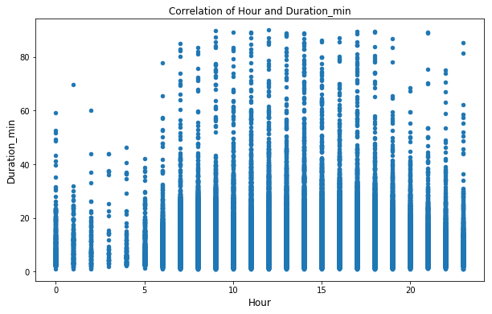

```python
#investigate the relationship between Hour and duration_min
df_final.plot(x='hour',y='duration_min',kind='scatter',title = "Correlation of Hour and Duration_min",figsize=(10,6));
plt.xlabel('Hour', fontsize= 12)
plt.ylabel('Duration_min', fontsize= 12);
```

In this scatter plot, we see that the duration min is similiar on most of the hour except for the morning time. Therefore,we cannot say duration min is depend on the hour.

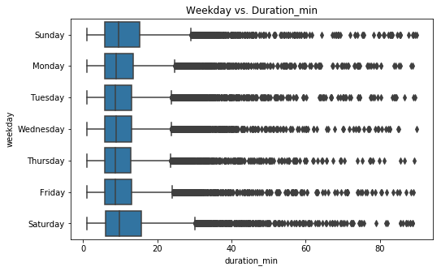

```python
#investigate the relationship between weekday and duration_min
base_color = sb.color_palette()[0]
plt.figure(figsize=[8, 5])
plt.title('Weekday vs. Duration_min')
sb.boxplot(data = df_final, x = 'duration_min', y = 'weekday', color = base_color);
```

From this plot, we can see that the mean of duration_min for weekdays is around 10 mins and the distribution is very consistant. However, duration_min is longer for weekend.

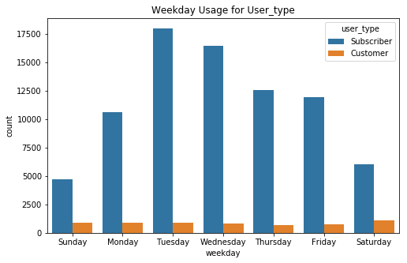

```python
#investigate the relationship between weekday and user type
plt.figure(figsize=[8, 5])
plt.title('Weekday Usage for User_type')
sb.countplot(data = df_final, x = 'weekday', hue = 'user_type');
```

The distribution shows that more subscribers use bike on weekdays than weekend, which reflects to the distribution we have in Univariate Exploration section. However, distribution is pretty consistant for customers.

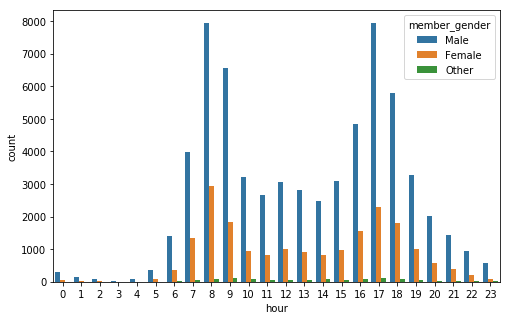

```python
#investigate the relationship between Hour and member gender
plt.figure(figsize=[8, 5])
sb.countplot(data = df_final, x = 'hour', hue = 'member_gender');
```

From this plot, we can see that both male and female members most likely use bike sharing system at 8 am and 5 pm.

```python
df_morning_start = df_final.query('hour == 8')
df_morning_start.start_station_name.value_counts().head()
```

```
San Francisco Caltrain Station 2  (Townsend St at 4th St)    552
San Francisco Ferry Building (Harry Bridges Plaza)           538
San Francisco Caltrain (Townsend St at 4th St)               491
Howard St at Beale St                                        430
Berry St at 4th St                                           276
Name: start_station_name, dtype: int64
```

```python
df_morning_end = df_final.query('hour == 8')
df_morning_end.end_station_name.value_counts().head()
```

```
The Embarcadero at Sansome St                       388
S Park St at 3rd St                                 381
Montgomery St BART Station (Market St at 2nd St)    355
Market St at 10th St                                338
Berry St at 4th St                                  332
Name: end_station_name, dtype: int64
```

At 8 am, more members were coming from the outskrits of the city and end up stopping in downtown San Francisco or Financial District. Since most of start stations are nearby caltrain and bart station, it show people use bike after taking other transportion to their workplace

### Talk about some of the relationships you observed in this part of the investigation. How did the feature(s) of interest vary with other features in the dataset?

> In the part of the investigation, I observed bike usage for weekdays is much higher than usage in weekends. However, it is consistant for customers. Whether male or female members, they are more likey to use bike at 8 am and 5 pm. For weekday, the average duration min for each ride is similar. Duration min for weekend is much longer.

### Did you observe any interesting relationships between the other features (not the main feature(s) of interest)?

> From the first plot, I obeserved the duration for the ride in the morning is shorter than the ride in the afternoon or evening. I was not expected this since the bike usage at noon and in the afternoon are less than in other times. Besides,even though female members are less than male members, the dirtribution of their usage in hour is similiar.
- When are most trips taken in terms of time of day, day of the week, or month of the year?
- How long does the average trip take?
- Does the above depend on if a user is a subscriber or customer?

## Multivariate Exploration

> Create plots of three or more variables to investigate your data even further. Make sure that your investigations are justified, and follow from your work in the previous sections.

```python
df_final.head()
```

|  | duration_min | start_time | end_time | start_station_id | start_station_name | start_station_latitude | start_station_longitude | end_station_id | end_station_name | end_station_latitude | end_station_longitude | bike_id | user_type | age | member_gender | bike_share_for_all_trip | hour | weekday |
| --- | --- | --- | --- | --- | --- | --- | --- | --- | --- | --- | --- | --- | --- | --- | --- | --- | --- | --- |
| 6 | 7.55 | 2018-01-31 23:53:53.632 | 2018-02-01 00:01:26.8050 | 110 | 17th & Folsom Street Park (17th St at Folsom St) | 37.763708 | -122.415204 | 134 | Valencia St at 24th St | 37.752428 | -122.420628 | 3571 | Subscriber | 30 | Male | No | 23 | Wednesday |
| 7 | 3.00 | 2018-01-31 23:52:09.903 | 2018-01-31 23:55:10.8070 | 81 | Berry St at 4th St | 37.775880 | -122.393170 | 93 | 4th St at Mission Bay Blvd S | 37.770407 | -122.391198 | 1403 | Subscriber | 38 | Male | No | 23 | Wednesday |
| 8 | 16.60 | 2018-01-31 23:34:56.004 | 2018-01-31 23:51:32.6740 | 134 | Valencia St at 24th St | 37.752428 | -122.420628 | 4 | Cyril Magnin St at Ellis St | 37.785881 | -122.408915 | 3675 | Subscriber | 31 | Male | Yes | 23 | Wednesday |
| 9 | 13.75 | 2018-01-31 23:34:14.027 | 2018-01-31 23:47:59.8090 | 305 | Ryland Park | 37.342725 | -121.895617 | 317 | San Salvador St at 9th St | 37.333955 | -121.877349 | 1453 | Subscriber | 24 | Female | Yes | 23 | Wednesday |
| 11 | 7.20 | 2018-01-31 23:34:26.484 | 2018-01-31 23:41:39.2970 | 89 | Division St at Potrero Ave | 37.769218 | -122.407646 | 43 | San Francisco Public Library (Grove St at Hyde... | 37.778768 | -122.415929 | 2928 | Subscriber | 25 | Male | No | 23 | Wednesday |

```python
df_final.describe()
```

|  | duration_min | start_station_id | start_station_latitude | start_station_longitude | end_station_id | end_station_latitude | end_station_longitude | bike_id | age | hour |
| --- | --- | --- | --- | --- | --- | --- | --- | --- | --- | --- |
| count | 86246.000000 | 86246.000000 | 86246.000000 | 86246.000000 | 86246.000000 | 86246.000000 | 86246.000000 | 86246.000000 | 86246.000000 | 86246.000000 |
| mean | 10.709397 | 104.055863 | 37.773577 | -122.361436 | 101.186235 | 37.773723 | -122.360461 | 2047.972068 | 36.882081 | 13.201517 |
| std | 7.732321 | 86.939779 | 0.085024 | 0.104653 | 85.717203 | 0.084801 | 0.103923 | 1092.553981 | 10.245546 | 4.679811 |
| min | 1.016667 | 3.000000 | 37.317298 | -122.444293 | 3.000000 | 37.317298 | -122.444293 | 11.000000 | 19.000000 | 0.000000 |
| 25% | 5.833333 | 30.000000 | 37.771662 | -122.412408 | 28.000000 | 37.772406 | -122.411306 | 1130.000000 | 29.000000 | 9.000000 |
| 50% | 8.883333 | 80.000000 | 37.781270 | -122.398525 | 77.000000 | 37.781270 | -122.397405 | 2150.000000 | 35.000000 | 13.000000 |
| 75% | 13.350000 | 160.000000 | 37.795392 | -122.390428 | 157.000000 | 37.795392 | -122.390428 | 3016.000000 | 43.000000 | 17.000000 |
| max | 89.916667 | 342.000000 | 37.880222 | -121.874119 | 342.000000 | 37.880222 | -121.874119 | 3744.000000 | 79.000000 | 23.000000 |

```python
#Get the popular start station
df_final.start_station_name.value_counts().head()
```

```
San Francisco Caltrain (Townsend St at 4th St)               2066
Berry St at 4th St                                           1955
Market St at 10th St                                         1870
San Francisco Caltrain Station 2  (Townsend St at 4th St)    1792
San Francisco Ferry Building (Harry Bridges Plaza)           1779
Name: start_station_name, dtype: int64
```

```python
#create dataframe with data that involves top three start stations
popular_stations = df_final[(df_final.start_station_name == 'San Francisco Caltrain (Townsend St at 4th St)')|
                    (df_final.start_station_name == 'Berry St at 4th St')|
                     (df_final.start_station_name == 'Market St at 10th St')]
popular_stations.head()
```

|  | duration_min | start_time | end_time | start_station_id | start_station_name | start_station_latitude | start_station_longitude | end_station_id | end_station_name | end_station_latitude | end_station_longitude | bike_id | user_type | age | member_gender | bike_share_for_all_trip | hour | weekday |
| --- | --- | --- | --- | --- | --- | --- | --- | --- | --- | --- | --- | --- | --- | --- | --- | --- | --- | --- |
| 7 | 3.000000 | 2018-01-31 23:52:09.903 | 2018-01-31 23:55:10.8070 | 81 | Berry St at 4th St | 37.775880 | -122.393170 | 93 | 4th St at Mission Bay Blvd S | 37.770407 | -122.391198 | 1403 | Subscriber | 38 | Male | No | 23 | Wednesday |
| 32 | 36.983333 | 2018-01-31 22:24:39.943 | 2018-01-31 23:01:39.5710 | 30 | San Francisco Caltrain (Townsend St at 4th St) | 37.776598 | -122.395282 | 81 | Berry St at 4th St | 37.775880 | -122.393170 | 1757 | Subscriber | 27 | Female | No | 22 | Wednesday |
| 41 | 3.700000 | 2018-01-31 22:44:28.364 | 2018-01-31 22:48:11.0220 | 58 | Market St at 10th St | 37.776619 | -122.417385 | 61 | Howard St at 8th St | 37.776513 | -122.411306 | 3483 | Subscriber | 47 | Male | No | 22 | Wednesday |
| 43 | 7.433333 | 2018-01-31 22:39:06.871 | 2018-01-31 22:46:33.1970 | 81 | Berry St at 4th St | 37.775880 | -122.393170 | 28 | The Embarcadero at Bryant St | 37.787168 | -122.388098 | 484 | Subscriber | 31 | Male | No | 22 | Wednesday |
| 63 | 12.583333 | 2018-01-31 22:18:05.666 | 2018-01-31 22:30:41.5840 | 30 | San Francisco Caltrain (Townsend St at 4th St) | 37.776598 | -122.395282 | 223 | 16th St Mission BART Station 2 | 37.764765 | -122.420091 | 1225 | Subscriber | 25 | Male | No | 22 | Wednesday |

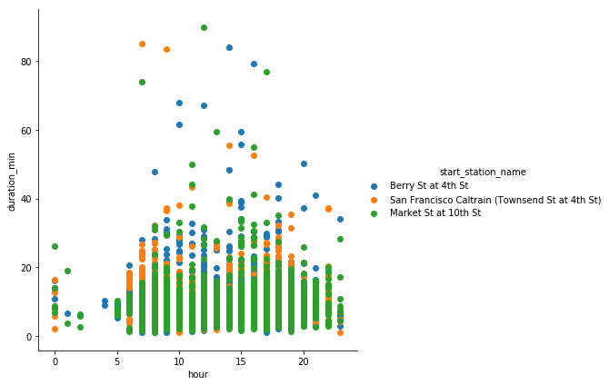

```python
#use scatter plot to see the relationship between hour and duration for popular station
g = sb.FacetGrid(data = popular_stations, hue = 'start_station_name', size = 6)
g.map(plt.scatter, 'hour', 'duration_min')
g.add_legend();
```

This distribution shows that people usually go to these popular stations from 8 am to 5 pm. Not many people use bike in the early morning. Also, most of them use bike for trips that are under 30 mins.

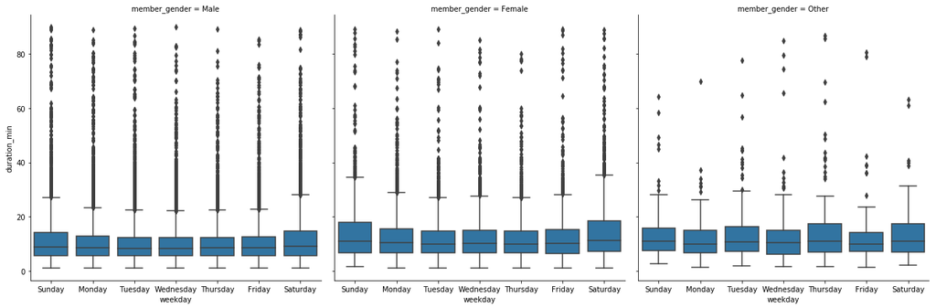

```python
#Create FaceGrid to invstigate duration min of different gender memeber each day
g = sb.FacetGrid(data = df_final, col = 'member_gender', size = 6)
g.map(sb.boxplot, 'weekday', 'duration_min');
```

From this Facegrid, we see that male members usually use bike for shorter time compare to female users even though there are more male members than female members in this database.

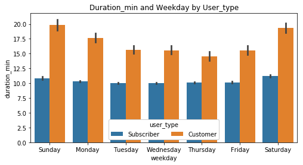

```python
#Create a clustered bar chart to investigate duration min of users each day
plt.figure(figsize=[8, 4])
ax = sb.barplot(data = df_final, x = 'weekday', y = 'duration_min', hue = 'user_type')
ax.legend(loc = 8, ncol = 3, framealpha = 1, title = 'user_type')
ax.set_title('Duration_min and Weekday by User_type');
```

From this clustered bar chart, we can see that the mean of duration min for subscriber is almost the same every day. However, customber usually use bikes for longer time during the weekend compare to weekdays.

### Talk about some of the relationships you observed in this part of the investigation. Were there features that strengthened each other in terms of looking at your feature(s) of interest?

> From previous sections, we see that bike users like to bike from 8 am to 5 pm and bike for longer time. I focus on top 3 popular station from the dataframe on plot 1. It indeed prove the observation we had. Also, from bivariate exploration, we know that the duration min for each day is about 10 mins. The third plot shows that the average trip subscriber take is 10 min every day. However, it varies for customer. Since customer is a small portion of this database, it does not make a big effect.